# Tableaux indexés ou listes en Python

## Type construit

Un tableau indexé est un type construit car c'est un objet dont les éléments sont des objets de types de base (ou éventuellement construit) :

**Exemple**

```python
T = [4, 7, 8, 1]
type(T)
```

```
list
```

- La variable `T` est un objet de type `list` en Python dont les éléments sont des objets de type `int`.
- Pour accéder aux éléments de `T`, on utilise son index :

```python
T[0] # Premier élément de T
```

```
4
```

```python
# Compléter
T[-1]  # Dernier élément de T
```

```
1
```

```python
# Compléter
T[1]  # Deuxième élément de T
```

```
7
```

## Une fonction et une méthode associées

La fonction `len` prend pour paramètre une liste et retourne sa taille : le nombre de ses éléments :

```python
# Compléter
len(T) # Taille de la liste T
```

```
4
```

La méthode `append` s'applique aux objets de type `list` et ajoute un élément à la fin de la liste :

```python
# Compléter
T.append(2)  # On ajoute l'entier 2 à la fin de la liste
T
```

```
[4, 7, 8, 1, 2]
```

## Parcourir les éléments d'une liste

### En utilisant les index :

```python
# Compléter
taille = len(T)  # Taille de la liste
for index in range(taille):
    print(T[index], end=', ')   # Affiche chaque élément de la liste
```

```
4, 7, 8, 1, 2,
```

### En parcourant chaque élément

```python
# Compléter
for element in T:
    print(element, end=', ')
```

```
4, 7, 8, 1, 2,
```

## La suite de Collatz

Sur le site **wikipedia.org**, on trouve les informations suivantes :

La suite de Syracuse(ou de Collatz) d'un nombre entier $N>0$ est définie par récurrence, de la manière suivante :

$u_0=N$ et pour tout entier naturel $n$, $u_{n+1}=\begin{cases}\dfrac{u_n}{2}\text{ si }u_n\text{ est pair,}\\3u_n+1\text{ si }u_n\text{ est impair.}\end{cases}$

#### Exercice 1

**1.** Calculer, à la main, les dix premiers termes de la suite de Collatz lorsque $u_0=10$.

| $u_0$ | $u_1$ | $u_2$ | $u_3$ | $u_4$ | $u_5$ | $u_6$ |
| --- | --- | --- | --- | --- | --- | --- |
| 10 | 5 | 16 | 8 | 4 | 2 | 1 |

**2.** Reprendre le travail pour $u_0=21$.

| $u_0$ | $u_1$ | $u_2$ | $u_3$ | $u_4$ | $u_5$ | $u_6$ | $u_7$ |
| --- | --- | --- | --- | --- | --- | --- | --- |
| 21 | 64 | 32 | 16 | 8 | 4 | 2 | 1 |

### Conjecture de Syracuse

La conjecture de Syracuse affirme que pour tout $N$, il existe un indice $n$ tel que $u_n = 1$.

L'observation graphique de la suite pour $N = 15$ et pour $N = 127$ montre que la suite peut s'élever assez haut avant de retomber. Les graphiques font penser à la chute chaotique d'un grêlon ou bien à la trajectoire d'une feuille emportée par le vent. De cette observation est né tout un vocabulaire imagé : on parlera du vol de la suite.

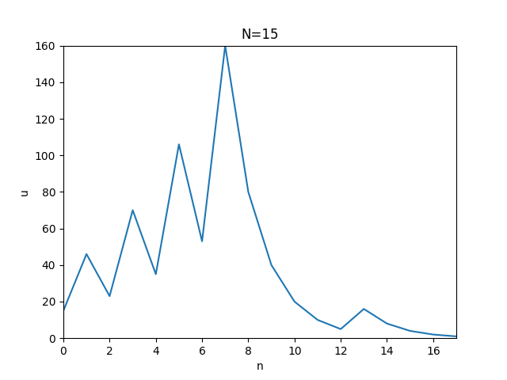

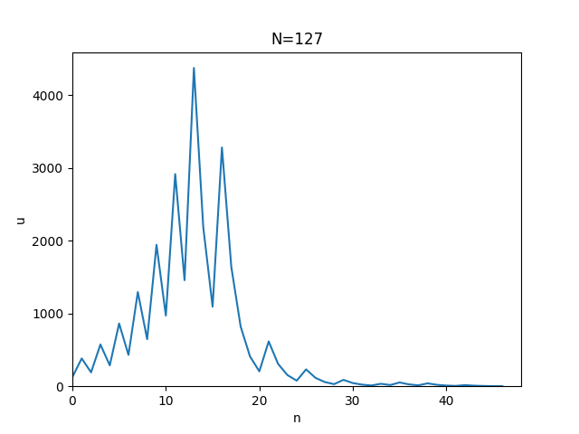

### Exercice 2

**1.** Écrire un algorithme (en langage courant) affichant tous les termes de la suite de Collatz jusqu'à afficher le premier terme égale à 1.

> Saisir `N`  
> `U` $\leftarrow$ `N`  
> Tant que `U > 1` faire  
> Si `U%2 = 0` alors  
> `U` $\leftarrow$ `U / 2`  
> Sinon  
> `U` $\leftarrow$ `3xU+1`  
> Afficher `U`  
> Afficher `U`

**2.** À l'aide de cet algorithme, compléter la fonction `collatz_indice` suivante qui prend pour paramètre un entier naturel `N` différent de zéro et retourne en sortie le plus petit indice `n` tel que $u_n=1$ : cet entier s'appelle le **temps de vol** de la suite de Collatz.

```python
# À compléter
def collatz_indice(N : int)-> int:
    """ Retourne le premier indice de la suite de Collatz du nombre N pour
    lequel le terme vaut 1
    """
    # Les instructions assert sont utilisées pour vérifier les préconditions.
    # Une telle instruction se compose d'une condition (une expression booléenne)
    # éventuellement suivie d'une virgule et d'une phrase en langue naturelle,
    # sous forme d'une chaine de caractères. L'instruction assert teste si sa condition est satisfaite.
    # Si c'est le cas, elle ne fait rien et sinon elle arrête immédiatement l'exécution du programme
    # en affichant éventuellement la phrase qui lui est associée.
    assert type(N) == int, "la variable N doit être de type int"
    assert N > 0, "la variable doit être un entier naturel non nul"
    # On commence la fonction
    indice = 0
    while N != 1:
        if N%2 == 0:
            N = N//2
        else:
            N = 3*N+1
        indice = indice + 1
    return indice
```

**3.** Vérifier que les préconditions fonctionnent pour 3.2 et -16.

```python
## Pour 3.2
collatz_indice(3.2)
```

```
---------------------------------------------------------------------------
AssertionError                            Traceback (most recent call last)
<ipython-input-10-0f55fb6d59a2> in <module>()
      1 ## Pour 3.2
----> 2 collatz_indice(3.2)

<ipython-input-9-8c916511c26e> in collatz_indice(N)
     10     # Si c'est le cas, elle ne fait rien et sinon elle arrête immédiatement l'exécution du programme
     11     # en affichant éventuellement la phrase qui lui est associée.
---> 12     assert type(N) == int, "la variable N doit être de type int"
     13     assert N > 0, "la variable doit être un entier naturel non nul"
     14     # On commence la fonction

AssertionError: la variable N doit être de type int
```

```python
### Pour -16
collatz_indice(-16)
```

```
---------------------------------------------------------------------------
AssertionError                            Traceback (most recent call last)
<ipython-input-11-ad29afdead03> in <module>()
      1 ### Pour -16
----> 2 collatz_indice(-16)

<ipython-input-9-8c916511c26e> in collatz_indice(N)
     11     # en affichant éventuellement la phrase qui lui est associée.
     12     assert type(N) == int, "la variable N doit être de type int"
---> 13     assert N > 0, "la variable doit être un entier naturel non nul"
     14     # On commence la fonction
     15     indice = 0

AssertionError: la variable doit être un entier naturel non nul
```

**4.** Vérifier que le **temps de vol** de la suite est 17 pour $u_0=15$ et 46 pour $u_0=127$ : $$\begin{array}{|*{22}{c|}}\hline u_0 & u_1& u_2& u_3 & u_4 & u_5 & u_6& u_7& u_8 & u_9 & u_{10}& u_{11}& u_{12}& u_{13} &u_{14}& u_{15} & u_{16} &u_{17}& u_{18}& u_{19}& u_{20}&\\\hline 15 & 46& 23& 70& 35& 106& 53& 160& 80& 40& 20& 10& 5 & 16& 8& 4 & 2 & 1 & 4 & 2 & 1 & ...\\\hline \end{array}$$

```python
N = 15
print(f"Temps de vol pour N = {N} : {collatz_indice(N)}")
N = 127
print(f"Temps de vol pour N = {N} : {collatz_indice(N)}")
```

```
Temps de vol pour N = 15 : 17
Temps de vol pour N = 127 : 46
```

**5.** Écrire la fonction `collatz_liste` ayant comme paramètre d'entrée un entier naturel $N$ et retournant en sortie la partie de la suite de Syracuse tronquée au premier terme égal à $1$. Par exemple : `collatz(15)` retourne la liste `[15,46,23,70,35,106,53,160,80,40,20,10,5,16,8,4,2,1]`.

```python
def collatz_liste(N : int)-> list:
    """     Retourne une liste contenant les premiers termes de la uite de Collatz
    du nombre N tronquée au premier terme égal à 1
    """
    assert type(N) == int, "la variable N doit être de type int"
    assert N > 0, "la variable doit être un entier naturel non nul"
    # On commence la fonction
    U = [N]
    while N != 1:
        if N%2 == 0:
            N = N//2
        else:
            N = 3*N+1
        U.append(N)
    return U
```

```python
## Quelques tests :
N = 15
print(f"Liste pour N = {N} : {collatz_liste(N)}")
N = 21
print(f"Liste pour N = {N} : {collatz_liste(N)}")
```

```
Liste pour N = 15 : [15, 46, 23, 70, 35, 106, 53, 160, 80, 40, 20, 10, 5, 16, 8, 4, 2, 1]
Liste pour N = 21 : [21, 64, 32, 16, 8, 4, 2, 1]
```

### Pour allez plus loin

On définit alors :

- **le temps de vol en altitude :** c'est le plus petit indice $n$ tel que $u_{n+1} \leq u_0$.  
  Il est de 10 pour la suite de Syracuse $15$ et de $23$ pour la suite de Syracuse $127$ ;
- **l'altitude maximale :** c'est la valeur maximale de la suite.  
  Elle est de $160$ pour la suite de Syracuse $15$ et de $4\,372$ pour la suite de Syracuse $127$.

### Exercice 3

**1.** Écrire une fonction `vol_altitude` utilisant la fonction `collatz_liste`, ayant comme paramètre d'entrée un entier naturel `N` et retournant le temps de vol en altitude de la suite de Collatz du nombre $N$.

```python
def vol_altitude(N : int) -> int:
    """
    Retourne le temps de vol en altitude de la suite de Collatz.
    On utilise la fonction collatz_liste() (assert inutile)
    """
    indice = 0
    U = collatz_liste(N)
    while U[indice+1] > N:
        indice = indice + 1
    return indice
```

```python
## Quelques tests :
N = 15
print(f"Temps de vol en altitude pour N = {N} : {vol_altitude(N)}")
N = 127
print(f"Temps de vol en altitude pour N = {N} : {vol_altitude(N)}")
```

```
Temps de vol en altitude pour N = 15 : 10
Temps de vol en altitude pour N = 127 : 23
```

**2.** Écrire une fonction `altitude_max`, utilisant la fonction `collatz_liste`, ayant comme paramètre d'entrée un entier naturel `N` et retournant l'altitude maximale de la suite de Collatz du nombre $N$.

```python
def altitude_max(N : int) -> int:
    """
    Retourne l'altitude maximale de la suite de Collatz.
    On utilise la fonction collatz_liste()
    """
    maximum = N
    U = collatz_liste(N)
    for element in U:
        if element > maximum:
            maximum = element
    return maximum
```

```python
## Quelques tests :
N = 15
print(f"Altitude maximale pour N = {N} : {altitude_max(N)}")
N = 127
print(f"Altitude maximale pour N = {N} : {altitude_max(N)}")
```

```
Altitude maximale pour N = 15 : 160
Altitude maximale pour N = 127 : 4372
```

**3.** Écrire un programme demandant un entier à l'utilisateur et affichant les valeurs maximales des paramètres définis précédemment ainsi que les entiers correspondants, pour tout les entiers inférieurs ou égaux à l’entier saisit. Par exemple, on obtiendrait :

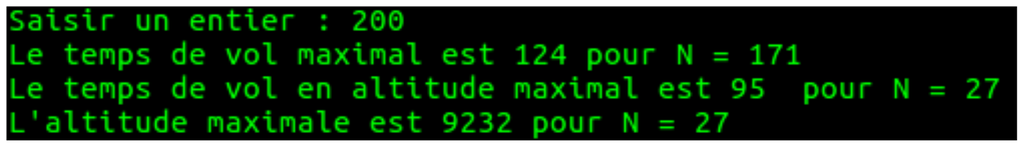

```python
entier = int(input("Saisir un entier : "))
vol_max = [0,0]
vol_altitude_max = [0,0]
max_altitude_max = [0,0]
for i in range(3, entier+1):
    if collatz_indice(i) > vol_max[0]:
        vol_max = [collatz_indice(i), i]
    if vol_altitude(i) > vol_altitude_max[0]:
        vol_altitude_max = [vol_altitude(i), i]
    if altitude_max(i) > max_altitude_max[0]:
        max_altitude_max = [altitude_max(i), i]
print(f"Le temps de vol maximal est {vol_max[0]} pour N = {vol_max[1]}")
print(f"Le temps de en altitude maximal est {vol_altitude_max[0]} pour N = {vol_altitude_max[1]}")
print(f"L'altitude maximale est {max_altitude_max[0]} pour N = {max_altitude_max[1]}")
```

```
Saisir un entier : 200
Le temps de vol maximal est 124 pour N = 171
Le temps de en altitude maximal est 95 pour N = 27
L'altitude maximale est 9232 pour N = 27
```